# Simulation Project

## Simulation 2 - Using RMSE for Selection

```r
library(readr)
sim2_data = read_csv("study_2.csv")
set.seed(19981127)#set seed for reproducable results
sigmas = c(1, 2, 4)#define sigma values for each simulation
n = 500 #sample size

rmse = function(actual, fitted) {
  sqrt(sum((actual - fitted)^2) / length((actual)))
}
rmse_sig1_train = data.frame(#initialize train rmse df - sigma=1
                    mod1_trn = rep(0, 1000),
                    mod2_trn = rep(0, 1000),
                    mod3_trn = rep(0, 1000),
                    mod4_trn = rep(0, 1000),
                    mod5_trn = rep(0, 1000),
                    mod6_trn = rep(0, 1000),
                    mod7_trn = rep(0, 1000),
                    mod8_trn = rep(0, 1000),
                    mod9_trn = rep(0, 1000)
                    )
rmse_sig2_train = data.frame(#initialize train rmse df - sigma=2
                    mod1_trn = rep(0, 1000),
                    mod2_trn = rep(0, 1000),
                    mod3_trn = rep(0, 1000),
                    mod4_trn = rep(0, 1000),
                    mod5_trn = rep(0, 1000),
                    mod6_trn = rep(0, 1000),
                    mod7_trn = rep(0, 1000),
                    mod8_trn = rep(0, 1000),
                    mod9_trn = rep(0, 1000)
                    )
rmse_sig3_train = data.frame(#initialize train rmse df - sigma=4
                    mod1_trn = rep(0, 1000),
                    mod2_trn = rep(0, 1000),
                    mod3_trn = rep(0, 1000),
                    mod4_trn = rep(0, 1000),
                    mod5_trn = rep(0, 1000),
                    mod6_trn = rep(0, 1000),
                    mod7_trn = rep(0, 1000),
                    mod8_trn = rep(0, 1000),
                    mod9_trn = rep(0, 1000)
                    )
rmse_sig1_test = data.frame(
                    mod1_tst = rep(0, 1000),
                    mod2_tst = rep(0, 1000),
                    mod3_tst = rep(0, 1000),
                    mod4_tst = rep(0, 1000),
                    mod5_tst = rep(0, 1000),
                    mod6_tst = rep(0, 1000),
                    mod7_tst = rep(0, 1000),
                    mod8_tst = rep(0, 1000),
                    mod9_tst = rep(0, 1000)
                    )
rmse_sig2_test = data.frame(
                    mod1_tst = rep(0, 1000),
                    mod2_tst = rep(0, 1000),
                    mod3_tst = rep(0, 1000),
                    mod4_tst = rep(0, 1000),
                    mod5_tst = rep(0, 1000),
                    mod6_tst = rep(0, 1000),
                    mod7_tst = rep(0, 1000),
                    mod8_tst = rep(0, 1000),
                    mod9_tst = rep(0, 1000)
                    )
rmse_sig3_test = data.frame(
                    mod1_tst = rep(0, 1000),
                    mod2_tst = rep(0, 1000),
                    mod3_tst = rep(0, 1000),
                    mod4_tst = rep(0, 1000),
                    mod5_tst = rep(0, 1000),
                    mod6_tst = rep(0, 1000),
                    mod7_tst = rep(0, 1000),
                    mod8_tst = rep(0, 1000),
                    mod9_tst = rep(0, 1000)
                    )
```

```r
##BEGIN SIMULATION
set.seed(19981128)
for (sig in sigmas) {
  for (i in 1:1000) {
    epsilon = rnorm(n, 0, sig)#generate error terms
    sim2_data$y = 0 + 5*sim2_data$x1 + -4*sim2_data$x2 + 1.6*sim2_data$x3 + -1.1*sim2_data$x4 + 0.7*sim2_data$x5 + 0.3*sim2_data$x6 + epsilon

    train_idx = sample(250)#create train index
    train = sim2_data[train_idx,]#set train to be data containing all columns and only rows in train index
    test = sim2_data[-train_idx,]#set test data to be all other data

    #start model creation
    mod1 = lm(y ~ x1, data = train)
    mod2 = lm(y ~ x1 + x2, data = train)
    mod3 = lm(y ~ x1 + x2 + x3, data = train)
    mod4 = lm(y ~ x1 + x2 + x3 + x4, data = train)
    mod5 = lm(y ~ x1 + x2 + x3 + x4 + x5, data = train)
    mod6 = lm(y ~ x1 + x2 + x3 + x4 + x5 + x6, data = train)#TRUE model
    mod7 = lm(y ~ x1 + x2 + x3 + x4 + x5 + x6 + x7, data = train)
    mod8 = lm(y ~ x1 + x2 + x3 + x4 + x5 + x6 + x7 + x8, data = train)
    mod9 = lm(y ~ x1 + x2 + x3 + x4 + x5 + x6 + x7 + x8 + x9, data = train)

    #calculate rmse for train and test data on each model
    if (sig == 1) {
      rmse_sig1_train$mod1_trn[i] = rmse(train$y, predict(mod1, train))
      rmse_sig1_test$mod1_tst[i] = rmse(test$y, predict(mod1, test))
      rmse_sig1_train$mod2_trn[i] = rmse(train$y, predict(mod2, train))
      rmse_sig1_test$mod2_tst[i] = rmse(test$y, predict(mod2, test))
      rmse_sig1_train$mod3_trn[i] = rmse(train$y, predict(mod3, train))
      rmse_sig1_test$mod3_tst[i] = rmse(test$y, predict(mod3, test))
      rmse_sig1_train$mod4_trn[i] = rmse(train$y, predict(mod4, train))
      rmse_sig1_test$mod4_tst[i] = rmse(test$y, predict(mod4, test))
      rmse_sig1_train$mod5_trn[i] = rmse(train$y, predict(mod5, train))
      rmse_sig1_test$mod5_tst[i] = rmse(test$y, predict(mod5, test))
      rmse_sig1_train$mod6_trn[i] = rmse(train$y, predict(mod6, train))
      rmse_sig1_test$mod6_tst[i] = rmse(test$y, predict(mod6, test))
      rmse_sig1_train$mod7_trn[i] = rmse(train$y, predict(mod7, train))
      rmse_sig1_test$mod7_tst[i] = rmse(test$y, predict(mod7, test))
      rmse_sig1_train$mod8_trn[i] = rmse(train$y, predict(mod8, train))
      rmse_sig1_test$mod8_tst[i] = rmse(test$y, predict(mod8, test))
      rmse_sig1_train$mod9_trn[i] = rmse(train$y, predict(mod9, train))
      rmse_sig1_test$mod9_tst[i] = rmse(test$y, predict(mod9, test))
    } else if (sig == 2) {
      rmse_sig2_train$mod1_trn[i] = rmse(train$y, predict(mod1, train))
      rmse_sig2_test$mod1_tst[i] = rmse(test$y, predict(mod1, test))
      rmse_sig2_train$mod2_trn[i] = rmse(train$y, predict(mod2, train))
      rmse_sig2_test$mod2_tst[i] = rmse(test$y, predict(mod2, test))
      rmse_sig2_train$mod3_trn[i] = rmse(train$y, predict(mod3, train))
      rmse_sig2_test$mod3_tst[i] = rmse(test$y, predict(mod3, test))
      rmse_sig2_train$mod4_trn[i] = rmse(train$y, predict(mod4, train))
      rmse_sig2_test$mod4_tst[i] = rmse(test$y, predict(mod4, test))
      rmse_sig2_train$mod5_trn[i] = rmse(train$y, predict(mod5, train))
      rmse_sig2_test$mod5_tst[i] = rmse(test$y, predict(mod5, test))
      rmse_sig2_train$mod6_trn[i] = rmse(train$y, predict(mod6, train))
      rmse_sig2_test$mod6_tst[i] = rmse(test$y, predict(mod6, test))
      rmse_sig2_train$mod7_trn[i] = rmse(train$y, predict(mod7, train))
      rmse_sig2_test$mod7_tst[i] = rmse(test$y, predict(mod7, test))
      rmse_sig2_train$mod8_trn[i] = rmse(train$y, predict(mod8, train))
      rmse_sig2_test$mod8_tst[i] = rmse(test$y, predict(mod8, test))
      rmse_sig2_train$mod9_trn[i] = rmse(train$y, predict(mod9, train))
      rmse_sig2_test$mod9_tst[i] = rmse(test$y, predict(mod9, test))
    } else {
      rmse_sig3_train$mod1_trn[i] = rmse(train$y, predict(mod1, train))
      rmse_sig3_test$mod1_tst[i] = rmse(test$y, predict(mod1, test))
      rmse_sig3_train$mod2_trn[i] = rmse(train$y, predict(mod2, train))
      rmse_sig3_test$mod2_tst[i] = rmse(test$y, predict(mod2, test))
      rmse_sig3_train$mod3_trn[i] = rmse(train$y, predict(mod3, train))
      rmse_sig3_test$mod3_tst[i] = rmse(test$y, predict(mod3, test))
      rmse_sig3_train$mod4_trn[i] = rmse(train$y, predict(mod4, train))
      rmse_sig3_test$mod4_tst[i] = rmse(test$y, predict(mod4, test))
      rmse_sig3_train$mod5_trn[i] = rmse(train$y, predict(mod5, train))
      rmse_sig3_test$mod5_tst[i] = rmse(test$y, predict(mod5, test))
      rmse_sig3_train$mod6_trn[i] = rmse(train$y, predict(mod6, train))
      rmse_sig3_test$mod6_tst[i] = rmse(test$y, predict(mod6, test))
      rmse_sig3_train$mod7_trn[i] = rmse(train$y, predict(mod7, train))
      rmse_sig3_test$mod7_tst[i] = rmse(test$y, predict(mod7, test))
      rmse_sig3_train$mod8_trn[i] = rmse(train$y, predict(mod8, train))
      rmse_sig3_test$mod8_tst[i] = rmse(test$y, predict(mod8, test))
      rmse_sig3_train$mod9_trn[i] = rmse(train$y, predict(mod9, train))
      rmse_sig3_test$mod9_tst[i] = rmse(test$y, predict(mod9, test))
    }
  }
}
```

**Results**

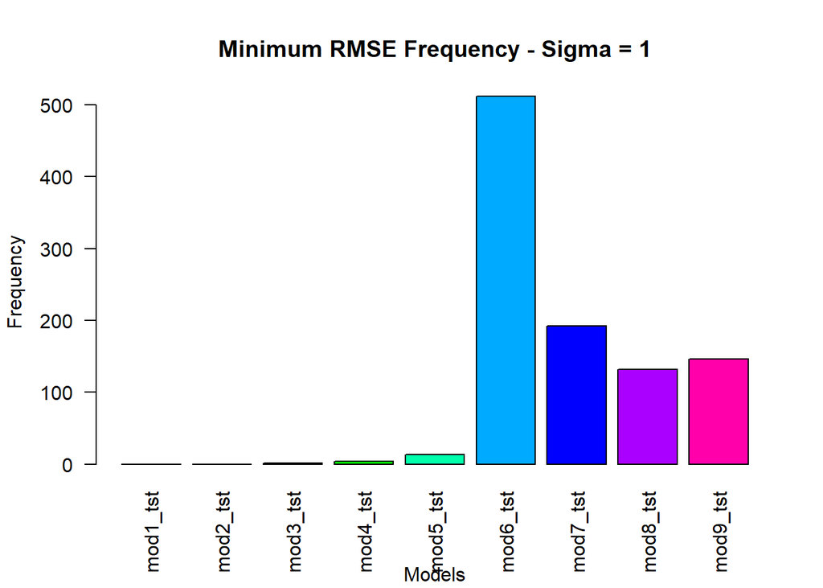

```r
#sigma = 1
barplot(
  table(factor(colnames(rmse_sig1_test)[apply(rmse_sig1_test, 1, FUN = which.min)], levels = colnames(rmse_sig1_test))),#use factor to include frequency's equal to zero
  main = "Minimum RMSE Frequency - Sigma = 1",
  sub = "Models",
  ylab = "Frequency",
  col = rainbow(9),#9 colors for 9 models
  las = 2#makes model names vertical
        )
```

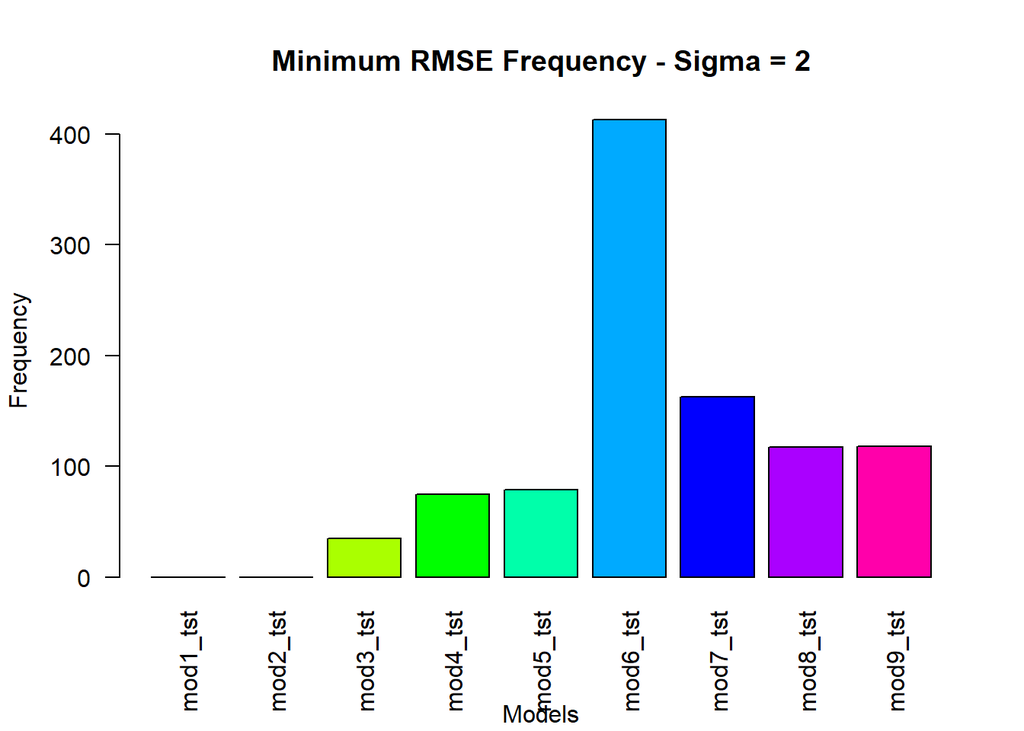

```r
#sigma = 2
barplot(
  table(factor(colnames(rmse_sig2_test)[apply(rmse_sig2_test, 1, FUN = which.min)], levels = colnames(rmse_sig2_test))),
  main = "Minimum RMSE Frequency - Sigma = 2",
  sub = "Models",
  ylab = "Frequency",
  col = rainbow(9),#9 colors for 9 models
  las = 2#makes model names vertical
        )
```

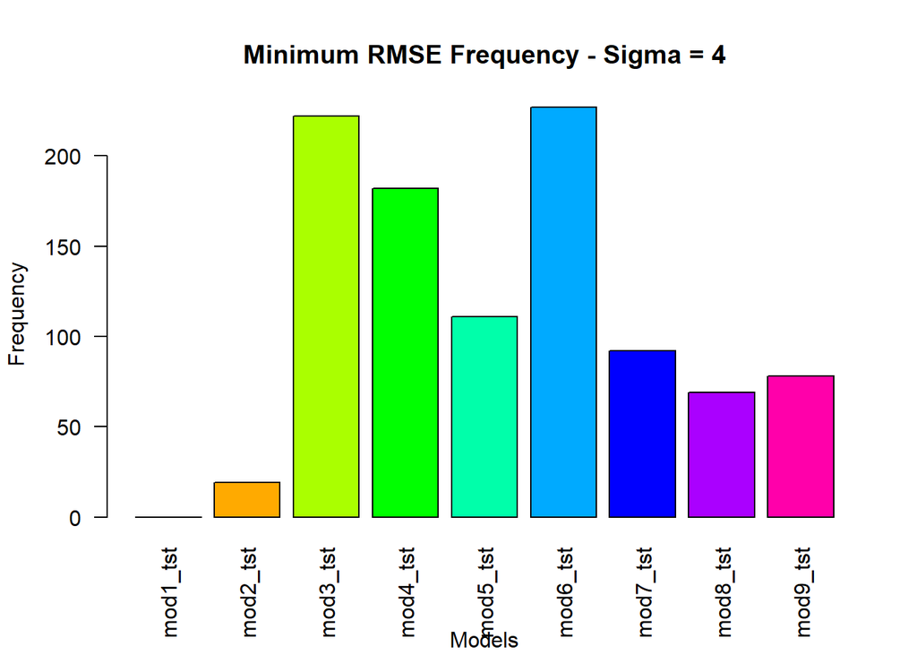

```r
#sigma = 4
barplot(
  table(factor(colnames(rmse_sig3_test)[apply(rmse_sig3_test, 1, FUN = which.min)], levels = colnames(rmse_sig3_test))),
  main = "Minimum RMSE Frequency - Sigma = 4",
  sub = "Models",
  ylab = "Frequency",
  col = rainbow(9),#9 colors for 9 models
  las = 2#makes model names vertical
        )
```

As we can see above, we are looking at the frequency of test data RMSE’s for each model being the lowest out of all models in each simulation over three levels of $\sigma$. As we can see, model 6 (which is the correct model), has the highest frequency of minimum RMSE’s on test data for all levels of $\sigma$. However, as $\sigma$ increases the models have more disturbance and become less predictable. This is reflected in the graphs above, as we can see that as $\sigma$ increases, the frequency of model 6 minimum RMSE’s on test data decreases (but stills remains the most frequent lowest RMSE).  
The table below displays the frequency of each model holding the lowest RMSE on test data per simulation, per value of $\sigma$.

|  | Model 1 | Model 2 | Model 3 | Model 4 | Model 5 | Model 6 | Model 7 | Model 8 | Model 9 |
| --- | --- | --- | --- | --- | --- | --- | --- | --- | --- |
| Frequency of min RMSE - Sigma = 1 | 0 | 0 | 1 | 4 | 13 | 512 | 192 | 132 | 146 |
| Frequency of min RMSE - Sigma = 2 | 0 | 0 | 35 | 75 | 79 | 413 | 163 | 117 | 118 |
| Frequency of min RMSE - Sigma = 4 | 0 | 19 | 222 | 182 | 111 | 227 | 92 | 69 | 78 |

The table below shows the average RMSE’s for each model on each level of $\sigma$ on train and test data.

```r
means = data.frame(
              Sigma1_TestData = colMeans(rmse_sig1_test),
              Sigma1_TrainData = colMeans(rmse_sig1_train),
              Sigma2_TestData = colMeans(rmse_sig2_test),
              Sigma2_TrainData = colMeans(rmse_sig2_train),
              Sigma4_TestData = colMeans(rmse_sig3_test),
              Sigma4_TrainData = colMeans(rmse_sig3_train)
              )
colnames(means) = c(
                    "Mean Test RMSE - Sigma = 1",
                    "Mean Train RMSE - Sigma = 1",
                    "Mean Test RMSE - Sigma = 2",
                    "Mean Train RMSE - Sigma = 2",
                    "Mean Test RMSE - Sigma = 4",
                    "Mean Train RMSE - Sigma = 4"
                    )
kable(t(means), col.names = c("Model 1 Mean RMSE", "Model 2 Mean RMSE", "Model 3 Mean RMSE", "Model 4 Mean RMSE", "Model 5 Mean RMSE", "Model 6 Mean RMSE", "Model 7 Mean RMSE", "Model 8 Mean RMSE", "Model 9 Mean RMSE"))
```

|  | Model 1 Mean RMSE | Model 2 Mean RMSE | Model 3 Mean RMSE | Model 4 Mean RMSE | Model 5 Mean RMSE | Model 6 Mean RMSE | Model 7 Mean RMSE | Model 8 Mean RMSE | Model 9 Mean RMSE |
| --- | --- | --- | --- | --- | --- | --- | --- | --- | --- |
| Mean Test RMSE - Sigma = 1 | 2.642385 | 1.584132 | 1.120792 | 1.072722 | 1.057123 | 1.0138248 | 1.015937 | 1.0176860 | 1.0197605 |
| Mean Train RMSE - Sigma = 1 | 2.429092 | 1.496630 | 1.084254 | 1.050622 | 1.032566 | 0.9822306 | 0.980304 | 0.9783268 | 0.9762311 |
| Mean Test RMSE - Sigma = 2 | 3.159890 | 2.346353 | 2.066123 | 2.043315 | 2.037445 | 2.0182918 | 2.022213 | 2.0260760 | 2.0300264 |
| Mean Train RMSE - Sigma = 2 | 2.982601 | 2.275290 | 2.027163 | 2.007308 | 1.994927 | 1.9664917 | 1.962511 | 1.9583143 | 1.9543575 |
| Mean Test RMSE - Sigma = 4 | 4.701410 | 4.207719 | 4.063503 | 4.058967 | 4.062613 | 4.0581149 | 4.067277 | 4.0746983 | 4.0825301 |
| Mean Train RMSE - Sigma = 4 | 4.568972 | 4.138418 | 3.997062 | 3.980277 | 3.968177 | 3.9500867 | 3.941791 | 3.9338418 | 3.9255669 |

So as we can see above, for all test data model 6 consistently holds the lowest average RMSE for each level of $\sigma$. However, for train data model 9 consistently holds the lowest average RMSE for each level of $\sigma$. I believe this difference in model selection for train/test data is due to the train data being used to build the models, and the model with the most variables is being selected therefore. However, when evaluating models it is more important that the model performs well on data it has not seen before, which is the test data. RMSE chooses model 6 consistently on average for the test data for each level of $\sigma$, so this tells me that model 6 overall is the best model (which it is since it is the true model), which means that model 6 performs the best on data it has not seen before. It also performs very similiar to model 9 on data it was created with.  
**Discussions**  
*Does RMSE always select the best model?*  
RMSE will not always select the best model, as discussed in the introduction section of this simulation. As we can see in the graphs above model 6 is the true model however RMSE does not always choose this model as the best in each simulation. However, on average we can expect RMSE to select the correct model. This is shown in the table above. RMSE will noe always select the best model as there is randomness in our data which will effect the predicting power in each model, and sway RMSE to choose a model separate from the true model that currently fits the data better. But, stated again, we see that over 1000 simulations that average RMSE will select the best model.  
*How does the level of noise affect the result?*  
The level of noise affects the results directly. As $\sigma$ increases, the model has larger disturbance terms which will lead the model to hold less predicting power, and make the model more random. When the data the model is trained on has more noise, RMSE will tend to not always choose the true model since the best model may be different due to the inflated noise. Looking at our graphs above, we can see this is the case. As the level of $\sigma$ increases, the frequency of RMSE choosing the true model (model 6), as the best model decreases. You can also see that the frequency of RMSE choosing each model starts to equal out, and becomes more uniform. Since the data becomes more random, it is harder to predict and model therefore leading to each model we created in the simulation holding relatively equal predicting power.

## Simulation 3 - Power

**Introduction**  
In this simulation, we will be looking at power in the significance of regression test. Recall from simulation 1 that the significance of regression test is testing whether any of the variables in the model are statistically significant. The null hypothesis in the significance of regression test is that none of the variables in the model are statistically significantly different than zero, and the alternative hypothesis is that at least one of the variables is statistically significantly different than zero. Power is looking specifically at the probability of rejecting the null hypothesis when the null is not true. So we are looking at the probability that the null hypothesis is rejected and the alternative hypothesis is accepted.  
Power can be written as this equation: 1 - $\beta$, where $\beta$ = P[Fail to reject $H_o$ | $H_1$ True]

Power can be effected in numerous ways by data, such as:  
- Sample size of data. The larger the sample, the higher the power you typically will get.  
- Signal Strength of $\beta_1$, your coefficient. If $\beta_1$ is close to zero, you will have lower power.  
- Noise level ($\sigma$). The larger $\sigma$ is, the less predictable your model and lower power therefore.  
- Significance level ($\alpha$). If $\alpha$ is lower, our power will be lower.

For this simulation in specific, we will focus only on sample size, signal strength of $\beta_1$, and Noise level ($\sigma$). The true model that we will be simulating in this simulation will be the following:
$Y_i$ = $B_0$ + $B_1$$x_i$ + $\epsilon_i$ - $\epsilon_i$ ~ N(0, $\sigma^2$)
In order to look at how signal strength of $\beta_1$ affects power, we will simulate different levels of $\beta$. In order to look at how $\sigma$ affects power, we will simulate different levels of $\sigma$. In order to look at how sample size affects power, we will simulate with different sample sizes.

**Methods**

```r
#incrementer function since R does not have +=
incrementer = function(variable, increment = 1) {
  variable + 1
}
```

```r
library(data.table)
#define variables
beta0 = 0
beta1s = seq(-2, 2, by = .1)#possible beta 1 values
sigmas = c(1, 2, 4)#levels of sigma we are using in simulation
sample_sizes = c(10, 20, 30)#sample sizes we are simulating from
alpha = .05 #significance level alpha

#how many models will be simulated per simulation? 3 for each sigma, 3 for each sample size, 41 for beta 1. This will be total number of powers we calculate.
total_rows = length(beta1s) * length(sample_sizes) * length(sigmas)
power_results = data.table(#each power will then correspond to a sigma, beta1, and n with this DF.
                  sigma = rep(0, total_rows),
                  beta1 = rep(0, total_rows),
                  n = rep(0, total_rows),
                  power = rep(0, total_rows)
                  )
power_results = as.vector(power_results)
#lets define an incrementer in order to put power in accurate row.
i = 1
start_time = Sys.time()
for (sig in sigmas){#simulate for all sigma levels
  for (n in sample_sizes){#simulate for all sample sizes

    x_values = seq(0, 5, length = n)#define x values of size n for this sample size
    #now we loop through possible beta values to create models for each one.
    for (beta1 in beta1s){
      #define total rejects for this beta1. We start at 0
      total_rejects = 0
      #for each beta1 in beta1s... simulate 1000 models.
      for (sim in 1:1000){
        epsilon = rnorm(n, 0, sig)#generate error terms
        y = 0 + beta1*x_values + epsilon
        temp_mod = lm(y ~ x_values)#build model
        p_value = summary(temp_mod)$coefficients[2, 4]#get pvalue for significance of regression test
        if (p_value < alpha){
          total_rejects = incrementer(total_rejects)

        }
      }
      #calculate power for this specific beta
      power = total_rejects / 1000 #1000 sims
      #results
      power_results[i, "sigma"]= sig
      power_results[i, "beta1"] = beta1
      power_results[i, "n"] = n
      power_results[i, "power"] = power

      #increase incrementer for row number
      i = incrementer(i)
    }
  }
}
end_time = Sys.time()
cat("took", end_time - start_time, "minutes to complete")
```

```
## took 4.707727 minutes to complete
```

```r
#using C++
```

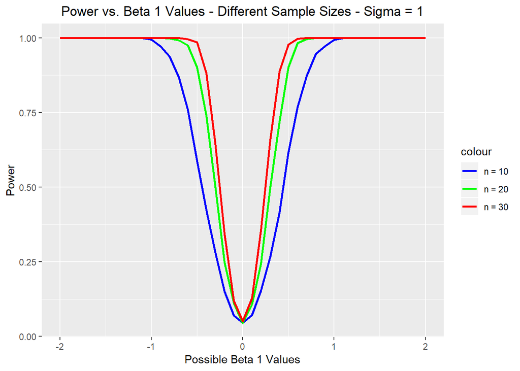

```r
##BEGIN PLOTTING
#ggplot2 is easier to use to plot curves. I will use it for plotting this simulation
library(ggplot2)
#clean data
power1 = power_results[which(power_results$sigma == 1),]
power1_n10 = power1[which(power1$n == 10),]
power1_n20 = power1[which(power1$n == 20),c("n", "power")]
power1_n30 = power1[which(power1$n == 30),c("n", "power")]
power1_full = cbind(power1_n10, power1_n20, power1_n30)
colnames(power1_full) = c("sigma", "beta1", "n10", "power_n10", "n20", "power_n20", "n30", "power_n30" )

power2 = power_results[which(power_results$sigma == 2),]
power2_n10 = power2[which(power2$n == 10),]
power2_n20 = power2[which(power2$n == 20),c("n", "power")]
power2_n30 = power2[which(power2$n == 30),c("n", "power")]
power2_full = cbind(power2_n10, power2_n20, power2_n30)
colnames(power2_full) = c("sigma", "beta1", "n10", "power_n10", "n20", "power_n20", "n30", "power_n30" )

power4 = power_results[which(power_results$sigma == 4),]
power4_n10 = power4[which(power4$n == 10),]
power4_n20 = power4[which(power4$n == 20),c("n", "power")]
power4_n30 = power4[which(power4$n == 30),c("n", "power")]
power4_full = cbind(power4_n10, power4_n20, power4_n30)
colnames(power4_full) = c("sigma", "beta1", "n10", "power_n10", "n20", "power_n20", "n30", "power_n30" )

ggplot(power1_full, aes(beta1)) +
  geom_line(aes(y = power_n10, color = "power_n10"), size=1) +
  geom_line(aes(y = power_n20, color = "power_n20"), size=1) +
  geom_line(aes(y = power_n30, color = "power_n30"), size=1) +
  xlab("Possible Beta 1 Values") +
  ylab("Power") +
  ggtitle("Power vs. Beta 1 Values - Different Sample Sizes - Sigma = 1") +
  scale_color_manual(
                      values = c("power_n10" = "blue", "power_n20" = "green", "power_n30" = "red"),
                      labels = c("n = 10", "n = 20", "n = 30")
                    ) +
  theme(plot.title = element_text(hjust = .5))
```

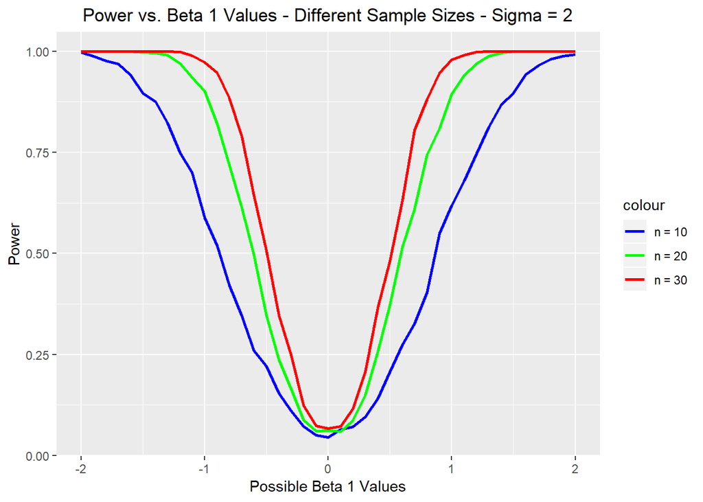

```r
ggplot(power2_full, aes(beta1)) +
  geom_line(aes(y = power_n10, color = "power_n10"), size=1) +
  geom_line(aes(y = power_n20, color = "power_n20"), size=1) +
  geom_line(aes(y = power_n30, color = "power_n30"), size=1) +
  xlab("Possible Beta 1 Values") +
  ylab("Power") +
  ggtitle("Power vs. Beta 1 Values - Different Sample Sizes - Sigma = 2") +
  scale_color_manual(
                      values = c("power_n10" = "blue", "power_n20" = "green", "power_n30" = "red"),
                      labels = c("n = 10", "n = 20", "n = 30")
                    ) +
  theme(plot.title = element_text(hjust = .5))
```

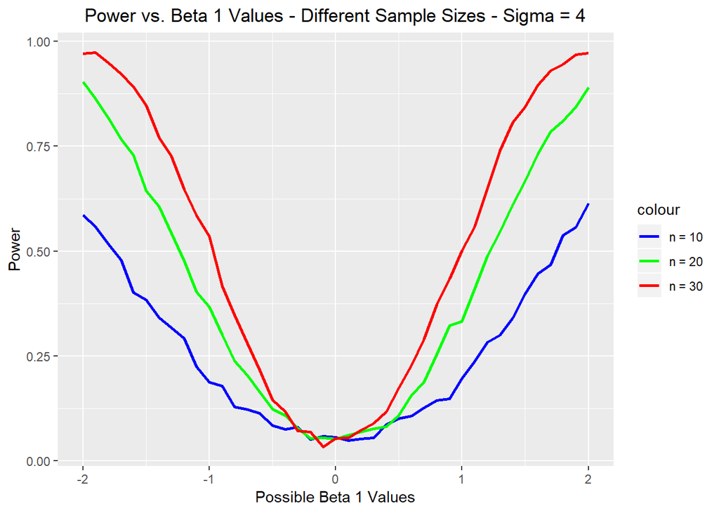

```r
ggplot(power4_full, aes(beta1)) +
  geom_line(aes(y = power_n10, color = "power_n10"), size=1) +
  geom_line(aes(y = power_n20, color = "power_n20"), size=1) +
  geom_line(aes(y = power_n30, color = "power_n30"), size=1) +
  xlab("Possible Beta 1 Values") +
  ylab("Power") +
  ggtitle("Power vs. Beta 1 Values - Different Sample Sizes - Sigma = 4") +
  scale_color_manual(
                      values = c("power_n10" = "blue", "power_n20" = "green", "power_n30" = "red"),
                      labels = c("n = 10", "n = 20", "n = 30")
                    ) +
  theme(plot.title = element_text(hjust = .5))
```

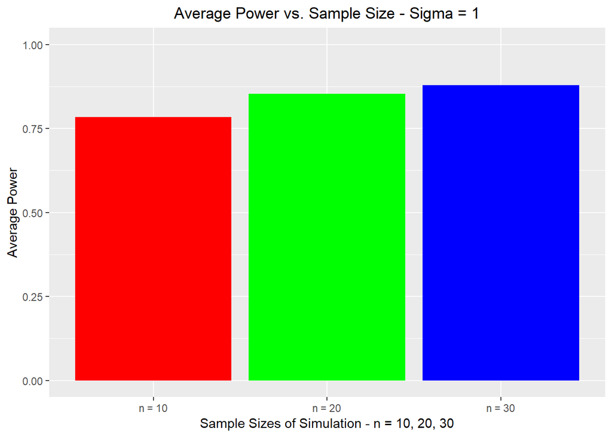

```r
ggplot(power1, aes(x = factor(n), y = power)) +
  stat_summary(fun.y = "mean", geom="bar", fill = rainbow(3)) +
  xlab("Sample Sizes of Simulation - n = 10, 20, 30") +
  ylab("Average Power") +
  ggtitle("Average Power vs. Sample Size - Sigma = 1") +
  theme(plot.title = element_text(hjust = .5)) +
  labs(color = "") +
  scale_x_discrete(breaks = c("10", "20", "30"),
                   labels = c("n = 10", "n = 20", "n = 30")
                   ) +
  ylim(0, 1)
```